..— title: “Poojitha Gowthaman - 71211593” Date: “24 July 2021” output: pdf_document: default html_document: default —

# QUESTION 1

fit a multiple linear regression model with price as the response using all available variables (except for name) as predictors.

```r
CarPrices <- read.csv('./CarPrice.csv')
```

### Question 1 Part (a)

Provide the summary R output

```r
carmlr <- lm(price ~ curbweight + enginesize + horsepower + peakrpm + citympg + highwaympg,
             data = CarPrices)
mlr <- summary(carmlr)
mlr
```

[output not shown]

### Question 1 part (b)

Write up the estimated equation of a line

Estimated Equation: price = -30810 + 5.93curbweight + 97.75*enginesize + 29.10*horsepower + 2.10*peakrpm - 38.11*citympg + 120.3*highwaympg

### Question 1 Part (c)

Interpret the estimated coefficient for the variable peakrpm.

The intercept of the peakrpm is measured to be 2.101e+00. We interpret the results as follows:

For a given value of curbweight, enginesize, horsepower, citympg and highwaympg, for every unit increase in peakrpm, the price of the car increases by a factor of approximately $2.1007. The p-value is less than 0.05 and this predictor is significant.

### Question 1 Part (d)

Perform “backward selection” manually using alpha = 0.05 as a threshold. That is, do not utilize any built-in R function to perform the selections for you. Provide commentary and R code for each step (but set results=“hide” in codechunk once you’re ready to submit to enhance readability).

BACKWARD SELECTION

```r
# Removing citympg
carmlr1 <- lm(price ~ curbweight + enginesize + horsepower + peakrpm + highwaympg, data = CarPrices)
summary(carmlr1)
```

```r
# Removing highwaympg
carmlr2 <- lm(price ~ curbweight + enginesize + horsepower + peakrpm , data = CarPrices)
summary(carmlr2)
```

```r
# Removing horsepower
carmlr3 <- lm(price ~ curbweight + enginesize + peakrpm , data = CarPrices)
summary(carmlr3)
```

```
##
## Call:
## lm(formula = price ~ curbweight + enginesize + peakrpm, data = CarPrices)
##
## Residuals:
##     Min      1Q  Median      3Q     Max
## -9479.3 -1781.2    40.1  1324.6 13196.4
##
## Coefficients:
##               Estimate Std. Error t value Pr(>|t|)
## (Intercept) -2.940e+04  3.262e+03  -9.012  < 2e-16 ***
## curbweight   5.606e+00  8.834e-01   6.346 1.44e-09 ***
## enginesize   1.156e+02  1.098e+01  10.523  < 2e-16 ***
## peakrpm      2.670e+00  5.230e-01   5.104 7.67e-07 ***
## ---
## Signif. codes:  0 '***' 0.001 '**' 0.01 '*' 0.05 '.' 0.1 ' ' 1
##
## Residual standard error: 3432 on 201 degrees of freedom
## Multiple R-squared:  0.8182, Adjusted R-squared:  0.8154
## F-statistic: 301.4 on 3 and 201 DF,  p-value: < 2.2e-16
```

### Question 1 part (e)

Discuss the resulting model, and consider comparing to the simple linear regression. What do you find interesting?

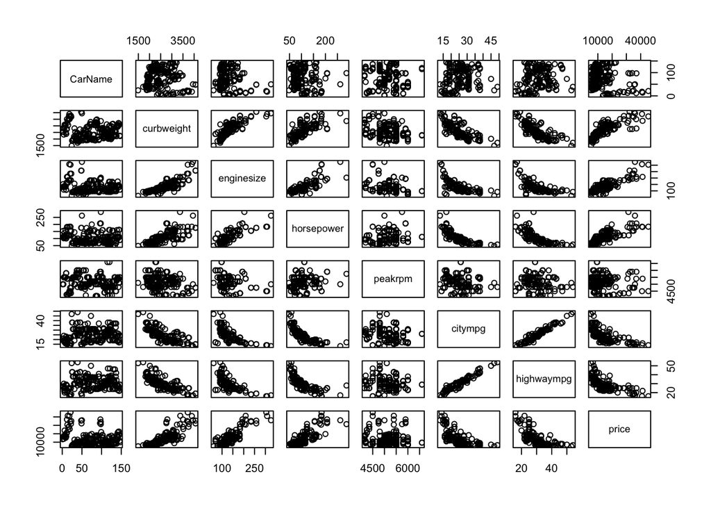

```r
plot(CarPrices)
```

The resulting model after backward selection gives a MLR with curbweight, enginesize and peakrpm as predictors and price as the response variable. We observe that these factors are “significant” in relation with the price of a car.

# QUESTION 2

Let X1 = GPA, X2 = IQ, X3 = Degree (1 for BEng and 0 for BSc), X4 = Interaction between GPA and IQ, and X5 = Interaction between GPA and Degree. Let the response be starting salary after graduation (in thousands of dollars). Suppose we use least squares to fit the model, and estimate beta0 =50,beta1 =20,beta2 =0.07,beta3 =35,beta4 =0.01,beta5 =−10.

```r
# for BEng
iq <- 10
gpa <- 4.0
degree <- 1
Y <- 50 + 20*gpa + 0.07 * iq + 35 * degree + 0.01 * (gpa*iq) - 10 *(gpa * degree)
Y
```

```
## [1] 126.1
```

```r
# For Bsc
iq <- 10
gpa <- 4.0
degree <- 0
Y <- 50 + 20*gpa + 0.07 * iq + 35 * degree + 0.01 * (gpa*iq) - 10 *(gpa * degree)
Y
```

```
## [1] 131.1
```

### Question 2 Part (a)

For a fixed value of IQ and GPA, BSc grads earn more on average than BEng grads. Option ii is correct

**Insights** * When GPA is 3.5 or above , BEng grads earn lower than BSc grads. Therefore, BSc grads earn more on average than BEng grads provided that their GPA is high enough.

- The coefficient of degree and the interaction coefficient of GPA and Degree become zero for Bsc Grads. We are left to deal with a simple equation Y = 50 + 20*gpa + 0.07* iq + 0.01(gpa*iq). The major weight is on the coefficient of GPA alone and the interaction coefficient of GPA and IQ contributes only to a unit increase of 0.01. Therefore for a higher GPA, the Bsc Grads would earn more.
- In the case of BEng grads, though we have the same amount of emphasis on GPA, we have a negative relationship on the interaction with GPA and Degree, so that’s probably pulling them down. High GPA alone may not be a factor in determining the average starting salary.

### Question 2 Part (b)

For a fixed value of IQ and GPA, BSc grads earn more on average than BEng grads provided that their GPA is high enough.

Simplified fitted equation for BEng

Starting Salary after graduation
$$\hat Y = 50 + X_1 (20 + 0.01X_2 - 10 X_3) + 0.07X_2 + 35X_3$$

After we substitute $X_3 = 1$:
$$\hat Y = 85 + X_1 (10 + 0.01X_2) + 0.07X_2$$

### Question 2 Part (c)

For a fixed value of IQ and GPA, BEng grads earn more on average than BSc grads

```r
iq <- 110
gpa <- 4.0
degree <- 1
Y <- 50 + gpa * ( (20 + 0.01 * iq) - 10 * degree) + (0.07 * iq) + (35 * degree)
Y
```

```
## [1] 137.1
```

**The predicted salary after graduation for BEng students with a GPA of 4 and IQ of 110 is $137100**

### Question 2 Part (d)

For a fixed value of IQ and GPA, BEng grads earn more on average than BSc grads provided that their GPA is high enough.

# QUESTION 3

Suppose data is collected with a single quantitative predictor and a quantitative response. A simple linear regression model is fit to the data, as well as a quartic regression: Quartic regression

$$Y = \beta_0 + \beta_1X_1 + \beta_2X_1^2 + \beta_3X_2^3 + \beta_4X_4^4 + \epsilon$$

### Question 3 Part (a)

Suppose that the true relationship between X and Y is linear. Which of the two models would we expect the training residual sum of squares (RSS) to be lower, or would we expect them to be the same? Justify your answer.

We are given that the true relationship between X and Y is linear, we would then expect the quartic to have a lower RSS for the training data. Even though we have a linear relationship, adding the quartic terms generates the need for the model to be more flexible. The quartic model gives a tighter fit to the data and expecting to have a lower RSS.

### Question 3 Part (b)

Answer (a) for test RSS instead. In the case of test data, we would need more information on how the data is coming in. We may assume that the quartic model would have a higher RSS for the test data. Flexible models have a higher variance and lower bias, however the bias that is reduced by the quartic model may not be necessarily offset by the reduction of variance by the linear model. (Simple models have a lower variance and higher bias). The flexible cubic model could potentially be overfit by the training the error contributed by the linear model. Therefore, we could certainly expect the RSS to be higher for the cubic model.

### Question 3 part (c)

Suppose the true relationship between X and Y is non-linear, to some unknown extent. Which of the two models would we expect the training residual sum of squares (RSS) to be lower, or would we expect them to be the same? Justify your answer.

In in the case of a non linear relationship, the quartic model would have a better fit the data with a lower RSS than the linear model. Irrespective of the underlying the true relationship, flexible models provide a tighter and close fit to all the data points. For the training data, we aim to reduce the RSS. So irrespective of the data being linear or non-linear, a flexible model would have a lower RSS.

### Question 3 part (d)

Answer (c) for test RSS instead. At this point, just the term “to unknown extent” should throw us off the bat slightly. When we have the test data, we are unable to side how truly non-linear or truly quartic Depending to what extent the true relationship is non linear, either of the two models can perform better. Let’s assume the test data that comes in is closer to the quartic model than the linear, then the quartic model tends to perform better(lower RSS). Vice - verse, if the test points are closer to the linear model, then linear model would perform better. It is going to be very difficult to arrive at a trade off between them.

# QUESTION 4

Use the rnorm() command to generate 80,000 standard normally distributed observations. Put those values into a ‘data.frame’ with 400 rows and 200 columns. Now fit a multiple linear regression where the fourteenth column of that matrix is the ‘response’ variable, and the remainder of the columns are considered predictors.

```r
set.seed(44547)
x <- rnorm(80000)
data <- data.frame(matrix(x, nrow = 400, ncol = 200))

normlr <- lm(data$X14 ~., data=data)
output <- summary(normlr)
output
```

[output not shown]

Examine the summary output for the model you just fit. Manually count the number of statistically significant (alpha = 0.05) predictor variables in this model. How many are there? What concept in class is this illustrating? How many statistically significant predictor variables would we expect to see for this simulation? **By manually observing the p-values for all the 199 columns, We count upto 12 predictors that are statistically significant.(counting the ones with asterisks)**

- This connects the concepts of multiple hypothesis tests on p predictors. Each predictor has an error rate associated with them. Accepting those error rates at 5% of the time, over 199 predictors, we are compounding the error rates for the 12 of them seen above. And, if we continue to do enough number of hypothesis, we are guaranteed that we would mess it up more than once. A 5% significance level would mean that we are we are erroneously rejecting the null hypothesis, and therefore erroneously conclude that the true relationship is zero, 5% of the time. Out of the 199 predictors, at 5% significance, we would expect to have 0.05*199 = 9.95 predictors to have a true linear relationship by chance (When actually it might not be possible as we have normal RVs as predictors), we would look for 10 predictors, and we have 12 which is acceptably close.

END OF ASSIGNMENT * * *